# Mercury Concentrations in Resident Lake Fish (2019-2020)

Sergio E. Sagastume

2025-04-24

# Introduction

Mercury contamination in aquatic ecosystems poses significant risks to wildlife and human health. This analysis investigates mercury concentrations in fish from Lake Clark National Park and Preserve (LACL) using data collected in 2019 and 2020. The project follows the Google Data Analytics framework to assess spatial differences, temporal trends, and species-specific health impacts of mercury contamination in resident fish.

# Scenario

These data were collected as part of the Southwest Alaska Inventory and Monitoring Network (SWAN) freshwater contaminants protocol. The dataset includes biological and lab data for 49 fish sampled from Lake Clark and Kijik Lake. Four species are represented: lake trout, burbot, Arctic grayling, and Arctic char.

# Ask

**Business Task:**  
Understand spatial differences, temporal trends, and health implications of mercury (Hg) contamination in fish species across Lake Clark and Kijik Lake in LACL. Use this analysis to support ecological monitoring and inform potential public health decisions.

# Prepare

```r
# Load and preview the data
SWAN_FW_Contaminants_Data_LACL_2019_2020 <- read_csv("SWAN_FW_Contaminants_Data_LACL_2019_2020.csv")
# Check structure and column names
glimpse(SWAN_FW_Contaminants_Data_LACL_2019_2020)
```

```
## Rows: 49
## Columns: 22
## $ Park           <chr> "LACL", "LACL", "LACL", "LACL", "LACL", "LACL", "LACL",…
## $ Lake           <chr> "Lake Clark", "Lake Clark", "Lake Clark", "Lake Clark",…
## $ Sample_ID_NPS  <chr> "LACL_lclar_LATR_01_2019", "LACL_lclar_LATR_02_2019", "…
## $ Sample_ID_USGS <chr> "MSC270AT", "MSC265AT", "MSC264AT", "MSC271AT", "MSC267…
## $ Species        <chr> "Lake trout", "Lake trout", "Lake trout", "Lake trout",…
## $ Date_Collected <chr> "6/13/2019", "6/13/2019", "6/13/2019", "6/18/2019", "6/…
## $ Date_Received  <chr> "10/1/2019", "11/1/2019", "11/1/2019", "11/1/2019", "11…
## $ Date_Analyzed  <chr> "2/20/2020", "2/20/2020", "2/19/2020", "2/20/2020", "2/…
## $ Latitude       <dbl> 60.28669, 60.28255, 60.28255, 60.23032, 60.23551, 60.23…
## $ Longitude      <dbl> -154.2237, -154.2342, -154.2342, -154.2357, -154.2326, …
## $ Length         <dbl> 521, 580, 544, 510, 500, 497, 543, 555, 595, 589, 530, …
## $ Gender         <chr> "F", "M", "M", "M", "F", "M", "M", "F", "F", "F", "F", …
## $ Weight         <dbl> 990, 1690, 1037, 1073, 897, 790, 1430, 857, 1610, 1500,…
## $ Age            <dbl> 8, 18, 13, 18, 10, 8, 17, 11, 18, 19, 9, 13, 19, 13, 12…
## $ Total_Hg       <dbl> 975, 1370, 1770, 2110, 1460, 1040, 1380, 1310, 1910, 21…
## $ Methyl_Hg      <dbl> NA, NA, NA, NA, NA, NA, NA, NA, NA, NA, NA, NA, NA, NA,…
## $ Moisture       <dbl> 77.3, 80.5, 80.7, 79.9, 79.9, 79.4, 78.2, 79.2, 78.6, 7…
## $ del_13C        <dbl> -26.86173, -22.79873, -27.60057, -27.06109, -27.61243, …
## $ Total_C        <dbl> -26.86173, -22.79873, -27.60057, -27.06109, -27.61243, …
## $ del_15N        <dbl> -26.86173, -22.79873, -27.60057, -27.06109, -27.61243, …
## $ Total_N        <dbl> -26.86173, -22.79873, -27.60057, -27.06109, -27.61243, …
## $ Comments       <chr> NA, NA, NA, NA, NA, NA, NA, NA, NA, NA, NA, NA, NA, NA,…
```

```r
# Filter out any rows with missing or irrelevant lake names
filtered_data <- SWAN_FW_Contaminants_Data_LACL_2019_2020 %>%
  filter(Lake %in% c("Lake Clark", "Kijik Lake"))
```

# Process

**Data Cleaning Steps:**  
1. Remove missing or inconsistent values  
2. Standardize column names for easy analysis  
3. Convert categorical variables (e.g., species names) into factors  
4. Aggregate data by **total_hg**, **length**, **weight** and **age**

```r
# Select and rename key variables
processed_data <- filtered_data %>%
  select(-Comments, -Methyl_Hg) %>%
  rename(
    total_hg = Total_Hg,
    length = Length,
    weight = Weight,
    age = Age
  )

# Filter out rows with missing values in key fields
processed_data <- processed_data %>%
  filter(!is.na(total_hg), !is.na(length), !is.na(weight), !is.na(age))

# Convert date column if applicable (if needed for temporal analysis)
processed_data$date <- mdy(processed_data$Date_Collected)

# Inspect cleaned data
summary(processed_data)
```

```
##      Park               Lake           Sample_ID_NPS      Sample_ID_USGS
##  Length:49          Length:49          Length:49          Length:49
##  Class :character   Class :character   Class :character   Class :character
##  Mode  :character   Mode  :character   Mode  :character   Mode  :character
##
##
##
##
##    Species          Date_Collected     Date_Received      Date_Analyzed
##  Length:49          Length:49          Length:49          Length:49
##  Class :character   Class :character   Class :character   Class :character
##  Mode  :character   Mode  :character   Mode  :character   Mode  :character
##
##
##
##
##     Latitude       Longitude          length       Gender
##  Min.   :60.18   Min.   :-154.5   Min.   :394   Length:49
##  1st Qu.:60.19   1st Qu.:-154.5   1st Qu.:444   Class :character
##  Median :60.28   Median :-154.4   Median :484   Mode  :character
##  Mean   :60.25   Mean   :-154.4   Mean   :495
##  3rd Qu.:60.29   3rd Qu.:-154.3   3rd Qu.:544
##  Max.   :60.31   Max.   :-154.2   Max.   :609
##
##      weight          age           total_hg         Moisture
##  Min.   : 420   Min.   : 5.00   Min.   : 146.0   Min.   :74.6
##  1st Qu.: 710   1st Qu.: 8.00   1st Qu.: 325.0   1st Qu.:77.3
##  Median : 920   Median :10.00   Median : 685.0   Median :78.6
##  Mean   : 970   Mean   :11.41   Mean   : 916.3   Mean   :78.3
##  3rd Qu.:1280   3rd Qu.:14.00   3rd Qu.:1390.0   3rd Qu.:79.5
##  Max.   :1860   Max.   :20.00   Max.   :2200.0   Max.   :81.6
##
##     del_13C          Total_C          del_15N          Total_N
##  Min.   :-28.55   Min.   :-28.55   Min.   :-28.55   Min.   :-28.55
##  1st Qu.:-26.97   1st Qu.:-26.97   1st Qu.:-26.97   1st Qu.:-26.97
##  Median :-26.34   Median :-26.34   Median :-26.34   Median :-26.34
##  Mean   :-25.18   Mean   :-25.18   Mean   :-25.18   Mean   :-25.18
##  3rd Qu.:-24.22   3rd Qu.:-24.22   3rd Qu.:-24.22   3rd Qu.:-24.22
##  Max.   :-16.54   Max.   :-16.54   Max.   :-16.54   Max.   :-16.54
##  NA's   :1        NA's   :1        NA's   :1        NA's   :1
##       date
##  Min.   :2019-06-13
##  1st Qu.:2019-06-17
##  Median :2019-06-19
##  Mean   :2019-07-24
##  3rd Qu.:2019-06-21
##  Max.   :2020-06-18
##
```

# Analyze

```r
# Summary stats by lake
summary_stats_lake <- processed_data %>%
  group_by(Lake) %>%
  summarise(
    avg_mercury = mean(total_hg, na.rm = TRUE),
    max_mercury = max(total_hg, na.rm = TRUE),
    sample_count = n()
  )
summary_stats_lake
```

```
## # A tibble: 2 × 4
##   Lake       avg_mercury max_mercury sample_count
##   <chr>            <dbl>       <dbl>        <int>
## 1 Kijik Lake        370.         793           23
## 2 Lake Clark       1399.        2200           26
```

```r
# Summary stats by species
summary_stats_species <- processed_data %>%
  group_by(Species) %>%
  summarise(
    avg_mercury = mean(total_hg, na.rm = TRUE),
    max_mercury = max(total_hg, na.rm = TRUE),
    sample_count = n()
  )
summary_stats_species
```

```
## # A tibble: 4 × 4
##   Species         avg_mercury max_mercury sample_count
##   <chr>                 <dbl>       <dbl>        <int>
## 1 Arctic char            146          146            1
## 2 Arctic grayling        290.         368            2
## 3 Burbot                 723          912            6
## 4 Lake trout             996.        2200           40
```

# Share

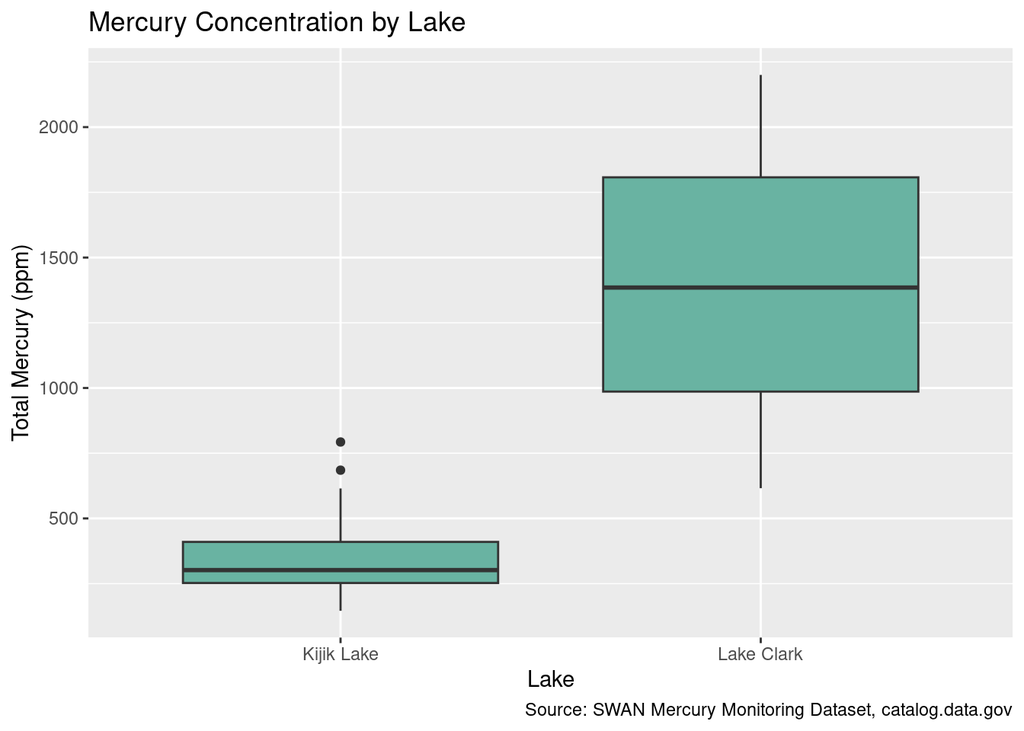

```r
# Plot: Mercury concentration by lake
ggplot(processed_data, aes(x = Lake, y = total_hg)) +
  geom_boxplot(fill = "#69b3a2") +
  labs(title = "Mercury Concentration by Lake",
       x = "Lake",
       y = "Total Mercury (ppm)",
       caption = "Source: SWAN Mercury Monitoring Dataset, catalog.data.gov")
```

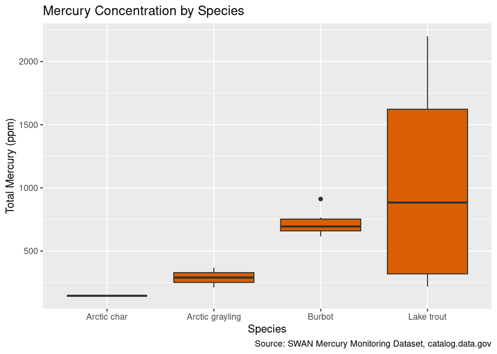

```r
# Plot: Mercury concentration by species
ggplot(processed_data, aes(x = Species, y = total_hg)) +
  geom_boxplot(fill = "#d95f02") +
  labs(title = "Mercury Concentration by Species",
       x = "Species",
       y = "Total Mercury (ppm)",
       caption = "Source: SWAN Mercury Monitoring Dataset, catalog.data.gov")
```

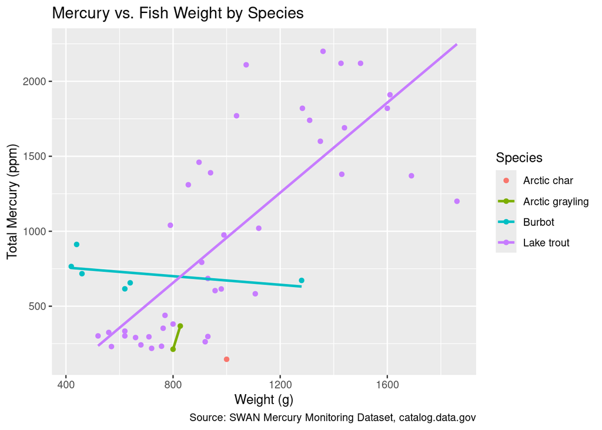

```r
# Optional: Relationship between mercury and weight
ggplot(processed_data, aes(x = weight, y = total_hg, color = Species)) +
  geom_point() +
  geom_smooth(method = "lm", se = FALSE) +
  labs(title = "Mercury vs. Fish Weight by Species",
       x = "Weight (g)",
       y = "Total Mercury (ppm)",
       caption = "Source: SWAN Mercury Monitoring Dataset, catalog.data.gov")
```

# Act

## Recommendations

1. **Continue targeted mercury monitoring** in Lake Clark and Kijik Lake, with an emphasis on long-term trends and year-to-year variability.
2. **Prioritize species** for further study and potential public health advisories due to elevated mercury concentrations.
3. **Share findings** to National Park Service ecologists, fisheries biologists, and public health officials to inform conservation and safety strategies.
4. **Collaborate with environmental researchers** contributing to mercury levels, such as glacial melt, sediment runoff, or wetland influence.
5. **Expand future monitoring** to additional years and nearby lakes to strengthen ecological understanding and assess regional patterns.
6. **Educate local communities** about mercury risks in fish consumption and promote responsible fishing and dietary choices.